# A uniform profit rate on LEEDS’s own MRIO: what it would cost, and what the standard commodity does not buy

The markup system the model runs, restated and checked; the profit-rate dispersion a uniform rate would have to erase; the maximum profit rate on three capital concepts; and a wage–profit frontier that is convex where Sraffa’s theorem says it should be straight

Author

LEEDS_MODEL — JUST2CE

Published

September 23, 2026

**Written:** 2026-09-23 · **Repo at:** `main` @ `43d98a5` **Computation:** `R/sraffian_price_system.R`, a standalone script — **nothing in the engine was changed for this work.** It reads the cached baseline of arm `submitted` (`output/scenarios/arms/submitted/runs/baseline.RDS`) at **t = 50**, a period well inside the 100-period run and well before the shock at t = 70. **Evidence:** `qmd/reports/2026-09-23-evidence/sraffian_measurements.csv` (31 named measurements) and `..._sectors.csv` (108 sectors × 14 columns). This document reads both and recomputes every regional aggregate from the sector file; no number below is carried forward from prose. **Re-verified 2026-09-23** after the `(12.13)` energy-reserves sign was restored to a branch on `leeds.eq_spec` and the `submitted` baseline cache was re-cut: the measurement file is byte-identical across that change, because the restoration moves only the `ken` row and no Sraffian input reads it.

# 1. The question, and why it is not a parameter change

## 1.1 The two price systems

LEEDS prices at a **sectoral markup**. For each of the 108 sectors the engine sets a markup $\mu_j$ over unit cost, calibrated once at $t = 1$, and carries it unchanged through the run. Profit per unit of output is whatever that markup yields; the **profit rate on capital is a residual**, and there is no mechanism anywhere in the model that equalises it across sectors. This is the “real competition” pricing of Shaikh — firms set prices on costs, and differential profit rates persist as the signal that drives, but never completes, the movement of capital.

The **Sraffian** system inverts the direction of determination. A single profit rate $r$ on capital advanced is the datum, and relative prices are the residual:

$$p' = (1 + r)\,p'A + w\,\ell'$$

with $A$ the matrix of technical coefficients and $\ell$ the vector of labour coefficients. Here $r$ is uniform by construction and prices adjust until it is.

The two systems coincide **only if the calibrated markups happen to equalise the implied profit rates.** That is an empirical question about this model’s numbers, not a matter of theoretical preference, and it is what this report settles.

## 1.2 What Işıkara and Mokre do, and why the comparison is to them

A note on the reference framework, because it is an empirical literature rather than a theoretical one. **Işıkara and Mokre** compute *prices of production* directly from national input–output tables: they take the observed $A$ matrix, impose a single economy-wide profit rate, solve for the price vector that system implies, and then ask how far the result sits from observed market prices. The purpose is falsification — the classical claim that market prices gravitate around prices of production is testable, and their method is how you test it on real data. Their treatment of fixed capital matters for what follows: they build an $n \times n$ depreciation matrix $D$ normalised from a fixed-capital *flow* matrix, so depreciation enters with a full sectoral structure.

Mapping LEEDS onto that framework is straightforward in form and awkward in substance. The $A$ matrix is there, and the labour coefficients are there ($\ell_j = 1/pr_j$, the reciprocal of productivity). What is not there is their $D$: this model’s fixed capital enters as $\mathrm{diag}(\delta^z \kappa_j)$, a diagonal with **exactly two distinct values** across 108 sectors. That limitation is not incidental and is returned to in §4.3 and §6.

## 1.3 Why this is not a parameter change

Installing a uniform profit rate would not be setting a switch. It would discard the $t = 1$ markup calibration that is the only reason the model reproduces the observed MRIO at all, and it would reopen the numéraire. The four measurements below quantify each of those costs.

# 2. M1 — the engine’s price equation, restated and checked

## 2.1 The restatement

The code’s price block is written sector by sector. In the engine’s own notation:

$$p_{t,j} = \frac{\bigl[(p_t A)_j - p_{t,j}\,a_{jj}\bigr](1+\mu_j)(1+\kappa_j \delta^z) + w_j/pr_j}
{1 - a_{jj}(1+\mu_j)}$$

Multiplying out the denominator and collecting terms gives a matrix form that can be inverted:

$$p' = p'H + \ell', \qquad
H = \tilde{A} M D + \hat{A} M, \qquad
p' = \ell'(I - H)^{-1}$$

where $M = \mathrm{diag}(1 + \mu)$, $D = \mathrm{diag}(1 + \kappa \delta)$, $\hat{A} = \mathrm{diag}(\mathrm{diag}\,A)$ is the own-sector diagonal, $\tilde{A} = A - \hat{A}$ is everything off it, and $\ell_j = w_j / pr_j$ is unit **wage cost** (the labour coefficient itself is $1/pr_j$).

**This is checked, not asserted.** The restated system reproduces the engine’s own $p_t$ vector at t = 50 to a maximum relative departure of **1.26e-14**. Everything in this report rests on that agreement; had it failed, nothing below would mean anything.

## 2.2 An asymmetry in the code, reported as found

The restatement exposes something in the engine that is worth stating plainly, because it falsifies a claim that has been made about the model in conversation.

**The own-sector input $a_{jj}$ carries the markup $(1+\mu_j)$ but not the capital factor $(1+\kappa_j\delta)$.** Every other input carries both. Structurally: the diagonal is subtracted out before the $(1+\kappa\delta)$ multiplication, and the denominator restores it without. That is visible in the matrix form above as the difference between the two terms of $H$ — $\tilde{A}MD$ carries $D$, $\hat{A}M$ does not.

Why it matters. The markup calibration at $t = 1$ (`model/code/run_model_2026.R:127-129`) enforces

$$(1+\mu_j)\,\bigl(\text{colSums}\,A\bigr)_j\,(1+\kappa_j\delta) + w_j/pr_j = 1$$

and it enforces it **exactly** — maximum deviation across 108 sectors 2.22e-16, which is machine epsilon. The calibration would therefore deliver $p_t = 1$ **if and only if** the price block treated $a_{jj}$ the same way the calibration identity does. It does not, and the residue is $a_{jj}(1+\mu_j)\kappa_j\delta$.

Measured, at t = 50:

| Statistic | Value | Basis |
| --- | --- | --- |
| median $p_{t,j}$ | 0.929222 | 108 sectors, engine $p_t$ at t = 50 |
| mean departure from 1 | -0.0720 | 108 sectors, engine $p_t$ at t = 50 |
| max $&#124;p_{t,j} - 1&#124;$ | 0.1247 | 108 sectors, engine $p_t$ at t = 50 |
| calibration identity, max deviation | 2.22e-16 | max_j \|(1+mu_j)colSums(A)_j(1+kappa_j delta) + w_j/pr_j - 1\| |
| restatement vs engine, max relative error | 1.26e-14 | max_j \|p_restated_j - p_t_j\| / \|p_t_j\|, engine run at t=50, arm submitted |

**So the statement “prices are 1 by calibration” is true at $t = 1$ only because the price block never runs there, and false by roughly 7% once it does.** Whether the asymmetry is intended is a question for Marco and JBF; it is recorded here as a finding, not fixed.

# 3. M2 — the profit rate the markup implies, and its dispersion

## 3.1 The capital concept, stated before the number

Per unit of output, the engine’s own accounting decomposes price as

$$p_j = (pA)_j + \underbrace{w_j/pr_j}_{\text{wages}} + \underbrace{\delta\,\kappa_j\,p_j}_{\text{depreciation}} + \Pi_j$$

with $\Pi_j$ the unit profit. Capital advanced per unit of output is $\kappa_j p_j$ — this is the **model’s own capital concept**, not one imported for this exercise: at `model/code/run_model_2026.R:141` sector $k$’s capital stock is $\kappa_k x_k$, valued at sector $k$’s *own* price. Hence

$$r_j = \frac{\Pi_j}{\kappa_j\,p_j}$$

a rate per period on **fixed capital only**. Circulating capital is not in the base, and that is a property of the model rather than a choice made here: LEEDS never advances circulating capital, so there is no stock of it to earn a return.

## 3.2 The dispersion

| Region | Median r_j | Capital-weighted mean | sd | CV | r_j < 0 |
| --- | --- | --- | --- | --- | --- |
| Z1 — EU | +0.3531 | +0.4384 | 0.3847 | 0.867 | 1 of 54 |
| Z2 — Rest of World | +0.2126 | +0.3533 | 0.3999 | 1.100 | 5 of 54 |
| **World, all 108** | +0.2908 | **+0.370387** | 0.3926 | **0.972** | 6 of 108 |

The capital-weighted world rate is $\bar{r} = +0.370387$ per period, against a standard deviation across sectors of 0.3926 and a range from -0.1592 to +2.0155.

**The coefficient of variation is 0.972. The dispersion is as large as the mean.** That single number is the size of the object a uniform profit rate would have to erase. It is not a second-order adjustment to a nearly-uniform structure; the sectoral profit rates in this model are not approximately equal in any useful sense.

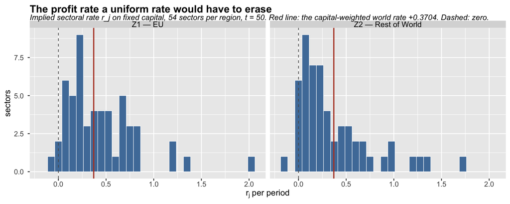

Six sectors of 108 carry a **negative** implied profit rate — one in the EU, five in the Rest of World. Under a markup system that is unremarkable (a markup over cost can still leave unit profit below the depreciation charge on the capital tied up). Under a uniform positive rate those six sectors cannot exist at all in that form, which is a further count of what the substitution would have to rearrange.

# 4. M3 — the maximum profit rate, and the wage–profit frontier

## 4.1 R depends on which capital is in the base

The maximum profit rate $R$ — the rate at which the wage falls to zero — is a property of the technique, but only once you have said which capital earns the rate. Three concepts are named here rather than one asserted, because the model is quietly ambiguous between them.

| Concept | Definition | Value |
| --- | --- | --- |
| $R_A$ | $1/\rho(A) - 1$ — circulating capital only | 0.884117 |
| $R_{AK}$ | root of $\rho\bigl((1+R)A + \mathrm{diag}((R + \delta^z)\kappa_j)\bigr) = 1$ — plus the model’s fixed capital | 0.424860 |
| $R_{\text{flow}}$ | $1/\rho\bigl(A + \mathrm{diag}(\delta^z \kappa_j)\bigr) - 1$ — Işıkara–Mokre’s depreciation-as-flow treatment | 0.575862 |

$\rho(A) = 0.530753$ is the Perron–Frobenius root of the technical matrix.

Two things follow, and they matter for how the model’s existing numbers are read.

**First, $R_A = 0.884117$ is the figure already sitting in `R/standard_commodity.R`, and it is the circulating-capital special case.** Calling it “the” maximum profit rate overstates it by roughly a factor of two against the fixed-capital concept $R_{AK} = 0.424860$, which is the one consistent with how §3.1’s profit rate was defined.

**Second, the measured $\bar{r} = 0.3704$ is 87% of $R_{AK}$.** That is extraordinarily high — it puts the system close to the wage-zero corner of its own frontier — and the reason is not a plausible profit share but the capital–output ratio.

**$\kappa$ takes exactly 2 distinct values across all 108 sectors** — 0.3250 in the EU and 0.3300 in the Rest of World. Two consequences. One, at roughly 0.33 it is an order of magnitude below any measured economy’s capital–output ratio of 2–3, which is what drives $r$ up: a small capital base under a given flow of profit yields a large rate. Two, **the profit rate’s base has no sectoral structure whatsoever.** This is open question 25 in `ai_context/04_OPEN_QUESTIONS.md`, and it is the binding constraint on the entire exercise — a uniform profit rate computed on a capital stock that varies over only two values is not measuring the thing the classical theory is about.

## 4.2 The wage–profit frontier, and the control that attributes its curvature

Sraffa’s construction is that with the **standard commodity** as numéraire, the wage–profit frontier becomes the straight line $w = 1 - r/R$. That linearity is the whole point of the standard commodity: it removes the price-change effects that otherwise make the trade-off between wages and profits depend on which bundle you measure them in.

Constructed here on the augmented system — standard net product of the augmented system as numéraire, wages advanced — the frontier is **not** straight:

| Quantity | Value |
| --- | --- |
| $w(0)$ | 4.5911 |
| $w(R_{AK}/2)$, measured | 1.8933 |
| $w(0)\,(1 - r/R)$ at $r = R_{AK}/2$ — what exact linearity requires | 2.2955 |
| ratio measured / linear | **0.8248** |
| **Control**: $w(R/2) \big/ [w(0)/2]$ in the single-matrix system $p' = (1+r)p'A + w\ell'$ | 1.00000001 |
| **Control**: curvature statistic in that system | 1.36e-15 |

The measured ratio is 0.8248, against 1 for exact linearity: **the frontier is convex.**

**The control is what makes this an attribution rather than an assertion.** Run the same curvature statistic on the textbook single-matrix system $p' = (1+r)p'A + w\ell'$, with $A$’s own standard net product as numéraire, and it returns 1.00000001 — linear to eight decimal places, curvature 1.36e-15, which is machine noise. So the non-linearity is not an artefact of the numerical construction, of the numéraire normalisation, or of a coding slip. It is produced by the two features that distinguish this system from the one Sraffa’s theorem is about: **wages are advanced, and fixed capital enters through a separately structured term $\mathrm{diag}((r + \delta)\kappa)$.**

## 4.3 What that costs the numéraire argument

This has a direct consequence for a decision already taken. The numéraire argument of 2026-09-18 (session log, “The numéraire, answered from the maintainer’s own document”) leans on choosing the standard commodity as numéraire to obtain the linear $w = 1 - r/R$ relation.

**In this model, that choice does not buy that relation.** The standard commodity linearises the frontier of the single-matrix system; it does not linearise the frontier of a system with advanced wages and a fixed-capital term. Adopting a uniform profit rate here therefore reopens the numéraire question without the tool that was expected to close it.

# 5. M4 — prices of production against the prices the engine runs

## 5.1 The system

Following Işıkara and Mokre, labour and capital inputs alike are multiplied by $(1+r)$ at a single average rate. In the model’s notation:

$$p_j = (1+r)\bigl[(pA)_j + w_j/pr_j\bigr] + (r + \delta^z)\,\kappa_j\,p_j$$

$$p'\bigl[\,I - (1+r)A - \mathrm{diag}\bigl((r + \delta^z)\kappa_j\bigr)\bigr] = (1+r)\,\ell'$$

evaluated at $r = \bar{r} = 0.370387$, the uniform rate that reproduces the model’s own aggregate. Both price vectors are then normalised to the **same** standard net product, so the comparison is of relative prices and not of an arbitrary scale.

## 5.2 How far apart they are

| Statistic | Value |
| --- | --- |
| mean absolute deviation | 29.95% |
| root mean square deviation | 37.64% |
| most negative deviation | -81.06% |
| most positive deviation | 86.21% |
| sectors within ±10% of the market price | 31 of 108 |
| sectors within ±25% of the market price | 52 of 108 |

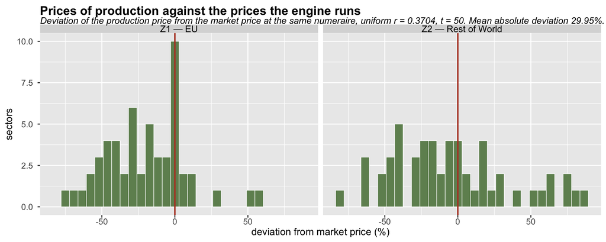

## 5.3 What the substitution would do to unit profits

The deviation in prices understates the disruption, because what is being replaced is the markup structure itself. Comparing unit profit at the uniform rate against unit profit at the calibrated markup:

| Statistic | Value |
| --- | --- |
| median ratio | 1.089 |
| 10th percentile | 0.300 |
| 90th percentile | 4.470 |
| **sectors that would more than halve or double** | **54 of 108** |
| spread of the calibrated $\mu$ itself (max / min) | 384.4-fold |

## 5.4 The correlation statistics, and why they are weak evidence

For completeness: Pearson correlation between the two price vectors is -0.617, Spearman -0.519.

**These are reported and should be given little weight, deliberately.** The engine’s $p_t$ spans only about 10.8% of its own median — *because* $\mu$ was calibrated to drive it to 1. A correlation computed against a near-constant vector is dominated by that vector’s residual, and its sign carries no information about gravitation. The **deviations and their distribution** in §5.2 are the informative statistics here; the correlation is not, and a negative correlation should not be read as evidence against the classical gravitation claim.

# 6. What the derivation settles

Installing a uniform profit rate in LEEDS is not a parameter change. It carries four distinct costs, each now measured:

1. **It discards the markup calibration.** The $t = 1$ calibration is the only reason the model reproduces the observed MRIO. 54 of 108 sectors’ unit profits move by more than a factor of two under the substitution (§5.3).
2. **It moves relative prices by about 30% on average**, with individual sectors moving from -81% to 86% (§5.2).
3. **It reopens the numéraire, and the standard commodity does not close it.** The wage–profit frontier of this system is convex, ratio 0.8248 against 1 for linearity, and the control establishes that the curvature comes from advanced wages plus the fixed-capital term rather than from the construction (§4.2).
4. **It requires a capital concept the model does not have.** Işıkara and Mokre’s $D$ is an $n \times n$ depreciation matrix normalised from a fixed-capital flow matrix. This model has $\mathrm{diag}(\delta^z \kappa_j)$ with 2 distinct values across 108 sectors (§4.1).

There is a fifth consideration, recorded on 2026-09-23 (§7 of that day’s session log) and **not re-measured here**, so it is flagged as carried rather than established by this document: in the conservation repo’s own falsification tests, production prices beat direct prices by only +0.67 points of a 16.1-point gap. If that holds, the empirical return to the whole substitution is small even where it is done properly.

# 7. What the derivation does not settle

## 7.1 One hundred and eight money wages

**The model assigns a different money wage to each of the 108 sectors.** Classical price theory assumes a uniform wage rate and lets the sectoral structure live in the labour coefficients.

The frontier in §4.2 was drawn by **scaling the observed 108-sector wage structure** — that is, by treating the relative wage dispersion as a datum and moving the whole vector up and down. That is a defensible reading, and it is the one that keeps the comparison against the engine honest, but it is not the classical construction. A genuinely Sraffian closure would have to choose between:

- a **uniform** $w$ with $\ell_j = 1/pr_j$ carrying all sectoral structure — the classical form; or
- the **observed wage dispersion** as a datum, which is what was done here.

The two give different frontiers, and nothing in this report adjudicates between them.

## 7.2 The price block’s diagonal asymmetry

§2.2’s finding — that $a_{jj}$ carries $(1+\mu_j)$ but not $(1+\kappa_j\delta)$ — is reported as found and not resolved. It is a question of intent for Marco and JBF. What can be said from here is what it costs: the calibration’s promise that $p_t = 1$ fails by a median of 7.1% once the price block runs, with a maximum departure of 0.1247.

## 7.3 The two-valued capital–output ratio

§4.1’s $\kappa$ finding is the constraint that limits everything else. Until fixed capital has sectoral structure, a uniform profit rate on this model’s capital base is a rate on an object with almost no cross-sectional variation, and the classical question it is supposed to answer cannot really be put to it.

All 31 measurements, with the basis of each. Source: qmd/reports/2026-09-23-evidence/sraffian_measurements.csv, regenerated 2026-09-23 against the re-cut `submitted` baseline.

| Measurement | Value | Basis — what it is a measurement of |
| --- | --- | --- |
| M1_restatement_max_rel_error | 0.0000000 | max_j \|p_restated_j - p_t_j\| / \|p_t_j\|, engine run at t=50, arm submitted |
| M1_p_t_median | 0.9292220 | engine p_t at t=50, 108 sectors |
| M1_calibration_identity_max_dev | 0.0000000 | max_j \|(1+mu_j)colSums(A)_j(1+kappa_j delta) + w_j/pr_j - 1\| |
| M1_p_t_max_dev_from_one | 0.1247194 | max_j \|p_t_j - 1\| at t=50 |
| M2_r_bar_world | 0.3703874 | sum_j Pi_j x_j / sum_j kappa_j p_j x_j at t=50 |
| M2_r_j_sd | 0.3926265 | sd over 108 sectors of the implied profit rate |
| M2_r_j_cv | 0.9724376 | sd / \|mean\| of r_j over 108 sectors |
| M2_r_j_negative_count | 6.0000000 | count of sectors with r_j < 0 of 108 |
| M2_r_j_min | -0.1592054 | min_j r_j |
| M2_r_j_max | 2.0155450 | max_j r_j |
| M3_R_A | 0.8841168 | 1/rho(A) - 1, circulating capital only, t=50 A matrix |
| M3_R_AK | 0.4248597 | root of rho((1+R)A + (R+delta)diag(kappa)) = 1 |
| M3_R_flow | 0.5758621 | 1/rho(A + delta diag(kappa)) - 1, depreciation as a flow |
| M3_frontier_w0 | 4.5910568 | wage at r=0, standard net product numeraire, wages advanced |
| M3_frontier_curvature | 0.0007332 | max\|2nd difference\| / range of w(r) over 41 points on [0, R_AK] |
| M3_frontier_w_half | 1.8933289 | w(R/2) on the augmented system, standard net product numeraire |
| M3_frontier_w_half_linear | 2.2955284 | w(0)(1 - r/R) at r = R/2 |
| M3_control_curvature | 0.0000000 | same curvature statistic for p = (1+r)pA + wl with A’s standard net product as numeraire |
| M3_control_w_half_ratio | 1.0000000 | w(R/2) / [w(0)/2] in the control system; 1 means exactly linear |
| M3_frontier_w_half_ratio | 0.8247900 | w(R/2) / [w(0)/2] in the augmented system; 1 would mean exactly linear |
| M4_within_10pc | 31.0000000 | count of 108 sectors with \|p_pp/p_t - 1\| <= 0.10 |
| M4_spearman | -0.5186487 | Spearman rank correlation of p_pp and p_t |
| M4_r_bar_used | 0.3703874 | the uniform rate at which prices of production are computed |
| M4_mad | 0.2995408 | mean_j \|p_pp_j/p_t_j - 1\|, both at the standard-net-product numeraire |
| M4_rms | 0.3763990 | sqrt(mean_j (p_pp_j/p_t_j - 1)^2) |
| M4_cor | -0.6166608 | Pearson correlation of p_pp and p_t at the same numeraire |
| M4_dev_min | -0.8105502 | min_j p_pp_j/p_t_j - 1 |
| M4_dev_max | 0.8621307 | max_j p_pp_j/p_t_j - 1 |
| M4_unit_profit_ratio_median | 1.0885062 | median_j (r_bar kappa_j p_j) / Pi_j at t=50 engine prices |
| M4_unit_profit_ratio_outside_half_double | 54.0000000 | count of 108 sectors whose unit profit would more than halve or double |
| M4_mu_spread | 384.3557811 | max_j mu_j / min_j mu_j, calibrated at t=1 |